# Le Travail Étudiant et la Réussite Universitaire

Youssef DIR & Nazifou AFOLABI

# Plan

- Revue de littérature
- Les données et les statistiques
- Les résultats

# Les principaux déterminants de la réussite

# Tableau des déterminants

| Variables | Auteurs | Effet.sur.le.Travail | Effet.sur.la.réussite |
| --- | --- | --- | --- |
| Age | sabia (2009) | Significatif | Significatif |
| genre | Béduwé et Giret (2004) | Significatif | Significatif |
| Niveau d’étude | Body et al (2014) | Non significatif | Significatif |
| Filière | Lixi, (2003) | Significatif | Significatif |
| Travail étudiant | Beffy et al (2009) |  | significatif |

# Les modèles économétriques

- MCO
- Les effets fixes
- Modèle des risques proportionnels de Cox
- Effets aléatoires
- **Probit bivarié**
- **Probit - Probit ordonné**

# Probit bivarié récursif

$$y_{i1} = \begin{cases} 1 & \text{si } y_{i1}^* > 0 \\
0 & \text{si } y_{i1}^* \leq 0 \end{cases}$$

$$y_{i2} = \begin{cases} 1 & \text{si } y_{i2}^* > 0 \\
0 & \text{si } y_{i2}^* \leq 0 \end{cases}$$

Avec :

$$y_{i1}^* = X_{i1}\beta_1 + u_{i1} \quad (1)$$

$$y_{i2}^* = \theta y_{i1} + X_{i2}\beta_2 + u_{i2} \quad (2)$$

# Modèle probit-probit ordonné

Un modèle avec une variable catégorielle : le temps de travail

$$\text{Pour tout } k \in \{0, 1, 2\},$$

$$Y_1 = k \Leftrightarrow s_k < Y_1^* = X_1\beta + u_{i1} \leq s_{k+1}$$

- Si $k = 0$, $Y_1^*$ représente l’absence de travail.
- Si $k = 1$, $Y_1^* \leq 16$ heures.
- Si $k = 2$, $Y_1^* \geq 16$ heures.

# Modèle probit-probit ordonné

On note dans la suite les variables indicatrices.

- $Y_1^{1}$ le fait de travailler moins de 16 heures.
- $Y_{1}^{2}$ le fait de travailler plus de 16 heures.

# Modèle probit-probit ordonné

Une variable catégorielle : la réussite universitaire

$$y_{i2} = \begin{cases} 1 & \text{si } y_{i2}^* > 0 \\
0 & \text{si } y_{i2}^* \leq 0 \end{cases}$$

avec:

$$y_{i2}^* = Y_1^1\beta_{20}^1 + Y_1^2\beta_{20}^2 + X_2\beta_{21} +
u_{i2}$$

# La fonction de vraisemblance

La contribution individuelle à la vraisemblance $P_1$ s’écrit, en notant $\Phi_2(.,.,\sigma_{12})$ la fonction de répartition de la loi normale bivariée $N(0, \Sigma)$, l’indice individuel $i$ étant omis ci-après afin d’alléger les notations:

$$\begin{align*}
P_1 &= \Phi_2(S_{y_1+1} - X_1\beta_1, -Y_{1}^1\beta_{20}^1 -
Y_{1}^2\beta_{20}^2 - X_2\beta_{21}, \sigma_{12}) \\
&\quad - \Phi_2(S_{y_1} - X_1\beta_1, - Y_{1}^1\beta_{20}^1 -
Y_{1}^2\beta_{20}^2 - X_2\beta_{21}, \sigma_{12})
\end{align*}$$

# La fonction de vraisemblance

De même, par symétrie, la contribution individuelle à la vraisemblance d’une observation du sous-échantillon $I_2$:

$$\begin{align*}
P_2 &= \Phi_2(S_{y_1+1} - X_1\beta_1, Y_{1}^1\beta_{20}^1 +
Y_{1}^2\beta_{20}^2 + X_2\beta_{21}, -\sigma_{12}) \\
&\quad - \Phi_2(S_{y_1} - X_1\beta_1, Y_{1}^1\beta_{20}^1 +
Y_{1}^2\beta_{20}^2 + X_2\beta_{21}, -\sigma_{12})
\end{align*}$$

## Les Données et les Travaux empiriques

# Les données

- Base de données : enquêtes de génération (2010)
- Sélection des variables pertinentes : 11 variables
- échantillon final (2548 observations avec 11 variables)

| Variables | Types |
| --- | --- |
| Homme | Qualitative |
| Master | Qualitative |
| Travail | Qualitative |
| Travail ordonné | Quantitative |
| Réussite | Qualitative |
| Filière | Qualitative |
| Enfant | Qualitative |
| Étranger | Qualitative |
| Bac | Qualitative |
| Age | catégorielle |
| Parents supérieurs | polytomique |

## Les Statistiques descriptives

| Variable | Modalités | Observations N=2548 (%) |
| --- | --- | --- |
| Homme | Non | 1249 (49%) |
|  | Oui | 1299 (51%) |
| Master | Non | 1178 (46%) |
|  | Oui | 1370 (54%) |
| Travail | Non | 2077 (82%) |
|  | Oui | 471 (18%) |
| Reussite | Non | 248 (10%) |
|  | Oui | 2300(90%) |
| Travail ordonné | Non | 2077 (82%) |
|  | Oui (=1) | 390 (15%) |
|  | Oui ($\geq$ 2) | 81 (3%) |

| Variable | Modalités | Observations N=2548 (%) |
| --- | --- | --- |
| Filière | Droit_eco_ges | 422 (17%) |
|  | Sce sociales | 411 (16%) |
|  | Sciences | 386 (15%) |
|  | Lettres_langues | 137 (5.4%) |
|  | Iut | 112 (4.4%) |
|  | Autres | 1080 (42%) |
| Enfant | Non | 2406 (94%) |
|  | Oui | 142 (6%) |
| Etranger | Non | 1497 (59%) |
|  | Oui | 1051 (41%) |

| Variable | Modalités | Observations N=2548 (%) |
| --- | --- | --- |
| Bac | Générale | 1849 (73%) |
|  | Professionnel | 86 (3.4%) |
|  | Technologique | 613 (24%) |
| parents sup | Aucun | 1285(50%) |
|  | Au moins un | 599 (24%) |
|  | Les deux | 664 (26%) |
| Âge | (17,21] | 565 (22%) |
|  | (21,25] | 1701 (67%) |
|  | (25,29] | 259 (10%) |
|  | (29,34] | 23 (1%) |

Statistiques descriptives

## Master - Réussite

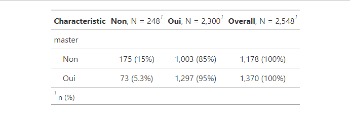

## Filière - Réussite

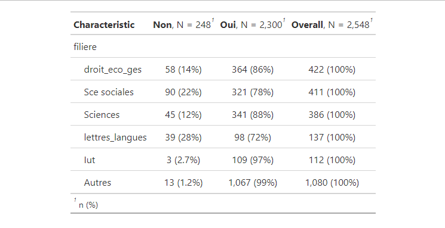

## Master - Travail

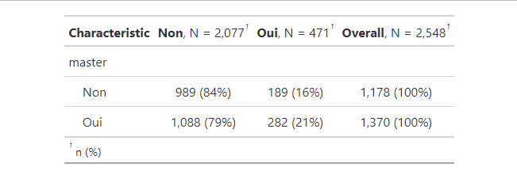

## Filière - Travail

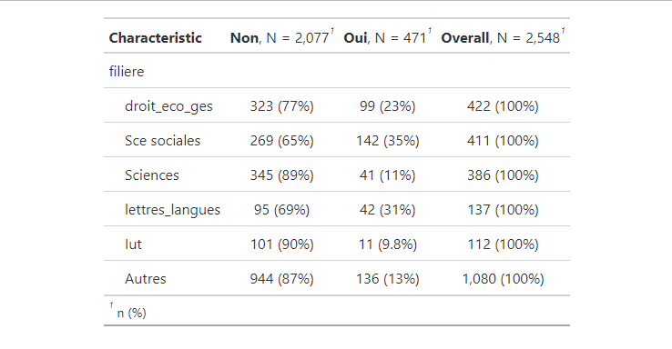

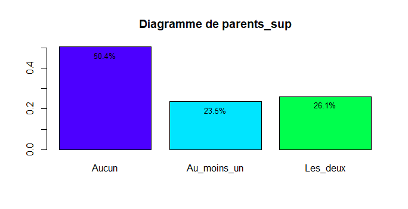

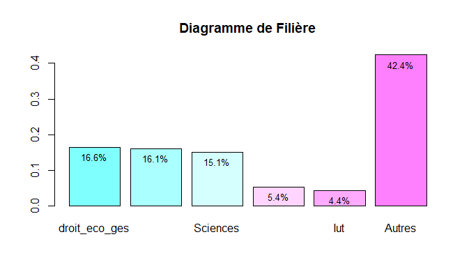

# Matrice de corrélation

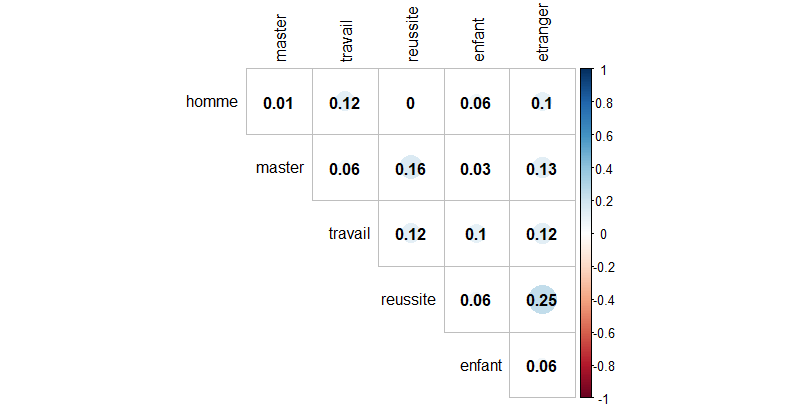

## Les modélisations économétriques.

- Sans prise en compte de l’endogénéité du travail

# Travail

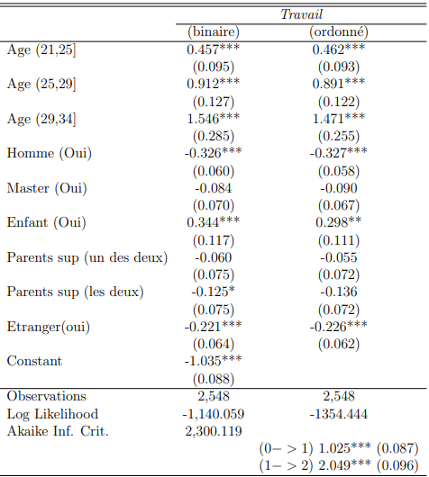

# Réussite

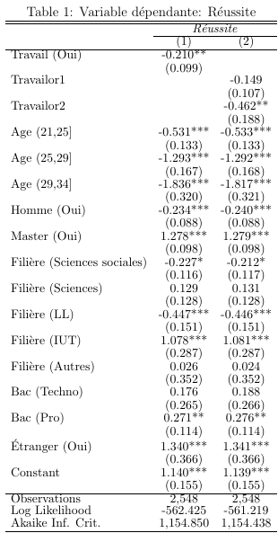

## Les modélisations économétriques.

- Prise en compte de l’endogénéité du travail

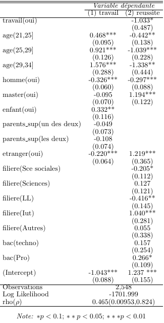

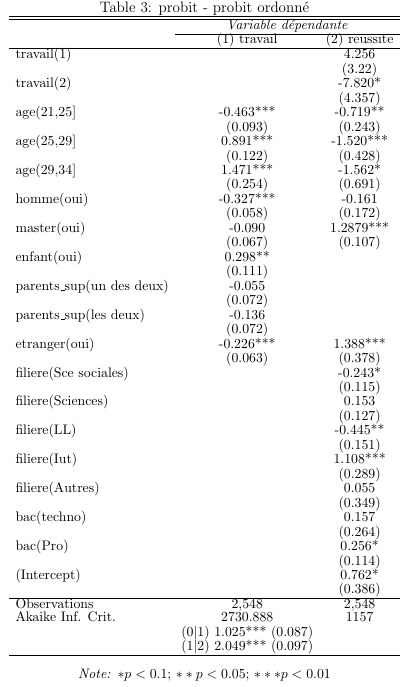

# Conclusion

- Concordance des résultats avec ceux des travaux anterieures.
- Consolider et validiter des resultats.